# Guide d’application

Anne Pinatel, Anne-Laure Girard, Dylan Clair, Eloise Galmiche, Eugénie Romette, Margot Challand, Salomé Hamard, Thomas Barrande, Valentine Neyret

15/05/2020

# 1 Définition du projet

Afin d’appliquer les connaissances acquises lors du module OPEN 2020, nous avons créer une application Shiny à l’aide de R et Rstudio.

Cette application a pour but de réaliser une analyse statistique d’un jeu de données.

# 2 Répartition des rôles

Notre groupe est composé de Anne Pinatel, Anne-Laure Girard, Dylan Clair, Eloise Galmiche, Eugénie Romette, Margot Challand, Salomé Hamard, Thomas Barrande et Valentine Neyret.

- Anne-Laure et Thomas se chargent d’importer les données sous R.
- Margot, Salomé et Dylan réalisent le codage de l’analyse statistique.
- Anne et Eugenie ont la charge de la mise en forme dans l’interface shiny.
- Eloise et Valentine réalisent le rapport explicatif du projet et ses étapes sous format PDF et Rmarkdown.

# 3 Application

Notre application réalise une ANOVA qui sert à vérifier que le facteur (variété) a une influence sur le résultat (rendement).

L’application vérifie tout d’abord que le jeu de données répond aux hypothèses nécessaires à la réalisation de cette analyse, c’est-à-dire que les valeurs sont indépendantes, normales et homoscédastiques. Ensuite, elle réaliseun test de Tukey pour comparer les valeurs deux à deux. Enfin, l’application réalise le test de Newman Keuls pour comparer et classer l’ensemble des résultats dans différents groupes de valeur proche.

Grace à cette application, nous pourrons donc connaitre les variétés donnant un meilleur rendement sur un interface ludique.

Le jeu de données utilisé comme exemple correspond à un essai agronomique dans l’Aude de 2019, et comprend des variétés de petit épeautre et leurs rendements.

Voici ci-dessous un aperçu de ces données :

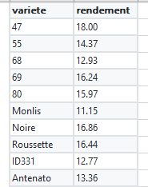

Apercu du tableau de données utilisé

# 4 Description de l’application

L’application est formée de trois onglets:

- Informations: L’onglet informations est ce que l’on pourrait assimiler à une page de garde. Ainsi, on y trouve les hypothèses de base, l’explication des données et leur provenance.
- Charger tableau: Dans cet onglet, on sélectionne le tableau de données à importer, qui s’affiche une fois chargé.
- Interprétation: L’onglet Interprétation est lui même formé de quatre onglets: Description, Hypothèses, Anova, Résultats.

# 5 Aide de lecture du dépôt Github

L’adresse du dépôt est la suivante : https://github.com/vneyret/Rapportfin

Le dossier Rapport fin comprend :

- Le dossier Projet_final : comprend l’interface shiny et les fichiers auxquels l’interface fait appel
- Le dossier Rapport intro : comprend tous les éléments faisant constituant le rapport final. Ce rapport s’appelle « Guide d’application » et a été créé en version PDF et Rmd
- Le dossier tableau : comprend les données auxquels le projet fait appel
- Le fichier Anova_final : le code R final pour les analyses statistiques
- Le guide d’application : ce guide permet la compréhension du projet

# 6 Conclusion du projet

Nous avons décidé de réaliser ce projet car étant tous des apprentis, nous souhaitions réaliser une application qui puisse nous être utile en entreprise.

Le projet initiale avait pour ambition d’analyser tous les jeux de données. Malheureusement, par manque de moyens, il ne fonctionne actuellemnt qu’avec notre jeu de données qui devait servir seulement d’exemple d’utilisation de l’application.

# 7 Conclusion du module OPEN

Malgré l’hétérogénéité de niveaux dans la classe et les circonstances, ce module a tout de même apporté des connaissances à chacun d’entre nous.

Etant Avignonnnais, nous avons une certaine expérience des cours en visio, et nous avons particulièrement apprécié les efforts dont tous les intervenants ont fait preuve lors de ce module. Ce sont des efforts rarement observés lors de cours donnés en visio, même quand la situation était moins critique. Nous vous remercions grandement pour ces efforts, vous nous avez réconciliés avec la visio.

**Merci!**